# Week 6: Estimation

PS 812 - Introduction to Statistical Methods in Political Science

Anton Strezhnev

strezhnev@wisc.edu

University of Wisconsin-Madison

October 13, 2026

## Welcome back!

$$\newcommand{\Var}{\text{Var}}
\newcommand{\Cov}{\text{Cov}}
\newcommand{\Corr}{\text{Corr}}
\newcommand{\indep}{\mathrel{\perp\mkern-10mu\perp}}$$

## Where we’ve been

Adapted from Blackwell (2025), Ch. 2

## Where we’re going

Adapted from Blackwell (2025), Ch. 2

## Defining the population

- Statistical **inference** is the task of learning about some feature of a target **population**
  - e.g. All U.S. voters
  - All voters *in Wisconsin*
  - All municipalities in the United States
  - All online reviews of restaurants
- The population is not (fully) observed
  - Otherwise we wouldn’t need statistics!
- In the case of a **finite** population, we could imagine listing the total number of units in the population $N$
  - This is our **sampling frame** (e.g. the voter file)

## Running Example: 2024 General Social Survey

[figure not shown]

- Our running example for today is the **General Social Survey** - a nationally representative survey of U.S. adults that has been conducting regular interviews since 1972.
- **Target population**: U.S. adults (18+) living in noninstitutional housing, April–December 2024
- **Sampling frame**: the NORC 2020 National Sampling Frame
  - A list of housing units built mostly from the USPS delivery file
  - Supplemented by NORC directly identifying addresses where USPS coverage is below 90%

## Defining the population

## Defining the estimand

- Our goal is to learn about some **feature** of the target population.
- We might be interested in the **distribution** of some variable $Y$ in that population
  - Turnout
  - Vote choice
  - Restaurant review score
- Often we want a **summary** of that distribution
  - An **expected value**: $\mathbb{E}[Y]$
  - Or, if we have two variables, a **regression function**: $\mathbb{E}[Y | X]$
- This is our **quantity of interest** or **estimand**
  - Often denoted with a *greek letter*: $\mu$, $\theta$, $\tau$

## Defining the estimand

## Running Example: 2024 General Social Survey

- We’ll focus on **self-reported** turnout in the 2020 U.S. presidential election

> “In 2020, you remember that Joe Biden ran for President on the Democratic ticket against Donald Trump for the Republicans. Do you remember for sure whether or not you voted in that election?”
- Let $\mathbb{E}[Y]$ denote the **expected turnout** in the target population
  - With a finite population, this is just the average of the response $Y_i$ of every member $i$
  - $Y_i = 1$ if voted, $Y_i = 0$ otherwise

$$\mu = \mathbb{E}[Y] = \frac{1}{N} \sum_{i=1}^N Y_i$$

## Sampling design

- We do not observe the population directly. Instead, we observe a **sample** from that population
  - Knowing the **sampling design** - how that sample was obtained - is **essential** to figuring out how what we calculate in sample relates to the target population.
- In statistics, we focus mainly on **probabilistic samples**
  - Let $Z_i = 1$ denote that unit $i$ is **sampled**
  - Let $n$ denote the size of the **sample**
- A **simple random sample** is a design where each sample of size $n$ has equal probability of occurring.
  - Let $\mathbf{Z} = (Z_1, \dotsc, Z_N)$ be the collection of sampling indicators

  $$P(\mathbf{Z}) = \begin{cases} 1/\binom{N}{n} & \text{if } \sum_{i=1}^N Z_i = n \\ 0 & \text{otherwise} \end{cases}$$
- $P(Z_i = 1) = \frac{n}{N}$ for all units.

## Sampling design

- A **Bernoulli** sampling design selects units by **independent** coin flips, each with some probability $p$

  $$P(Z_i = 1) = p \quad \forall i \in \{1, 2, \dotsc, N\}$$
- What’s the difference?
  - Under a Bernoulli design, sample size $n$ is **random**. Under an SRS, it’s **fixed**
  - Under a Bernoulli design, selection indicators are **independent**. Under an SRS, they’re (slightly) **dependent**.
- What’s the difference **in practice**?
  - None. If $N$ is **very large** relative to $n$, the two designs are indistinguishable
  - Under an SRS, learning that $i$ was sampled barely changes the chance that $j$ was: $P(Z_j = 1 \mid Z_i = 1) = \frac{n-1}{N-1} \approx \frac{n}{N} = P(Z_j = 1)$
  - Under a Bernoulli design, $n$ concentrates around $Np$. Conditional on $n$, a Bernoulli sample **is** an SRS.
  - e.g. the GSS: $n \approx 3{,}300$ out of $N \approx 260$ million adults

## Running Example: 2024 General Social Survey

- Real surveys are more involved. The 2024 GSS uses a **multi-stage cluster** design:
  1. Sample 74 **areas** (metros or groups of counties): 20 large areas with certainty, the rest w/ probability proportional to their number of housing units
  2. Within those, sample 400 **segments** (census tracts or block groups) (proportional to number of housing units)
  3. Within segments, sample 13,900 **addresses** so that every housing unit has the same chance of selection
  4. Within each responding household, select **one adult** at random
- This is **not** an SRS of adults
  - How do they correct this? **Weights!**

Source: 2024 GSS Cross-section Codebook, Release 3 (NORC), pp. 39–48

## Sampling design

## Estimators

- Once we have an **estimand** in mind, we want to figure out the *algorithm* to transform our sample of observations into a **best guess**.
  - Consider a **sample** of size $n$ with observations indexed by $i \in \{1,2, 3, \dotsc n\}$
- An **estimator** is a **function** of our sample.
  - It’s a random variable too!
- Since we’re targeting the **population mean**, a natural choice for an estimator would be the **sample mean**

  $$\hat{\mu} = \bar{Y}_n = \frac{1}{n} \sum_{i=1}^n Y_i$$
- We’ll often denote estimators with a **hat** put on top of the greek letter for the estimand: $\hat{\mu}$, $\hat{\theta}$, $\hat{\tau}$
  - Means are also often denoted with a **bar** on top of the variable

## Estimates

- An **estimate** is a single *realization* of an estimator
  - It’s the **number** that you calculate for **your** dataset.
- In the GSS, $n = 3{,}373$ respondents say whether they voted in 2020. The **sample mean** is

  $$\hat{\mu} = \bar{Y}_n = \frac{1}{n} \sum_{i=1}^n Y_i = 0.778$$
- An alternative estimator is the **weighted** mean using the **survey weight** $w_i$

  $$\hat{\mu}_w = \frac{\sum_{i=1}^n w_i Y_i}{\sum_{i=1}^n w_i} = 0.770$$

## Estimates in R

```r
library(tidyverse)

gss <- read_csv("data/gss2024.csv") |>
  filter(!is.na(voted20))   # said whether they voted in 2020

est <- gss |>
  summarize(n = n(),
            ybar = mean(voted20),
            ybar_w = weighted.mean(voted20, weight))
est
```

```
# A tibble: 1 × 3
      n  ybar ybar_w
  <int> <dbl>  <dbl>
1  3373 0.778  0.770
```

## Estimators are random variables

## Estimation

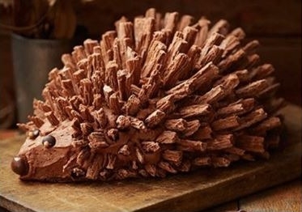

estimand

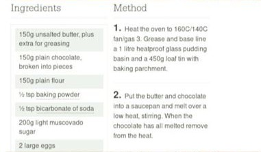

estimator

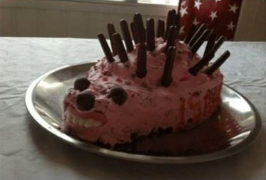

estimate

## Estimation

- How do we know if we’ve picked a good estimator?
  - Will it be close to the truth?
  - Will it be systematically higher or lower than the target?
- We cannot answer this question from our **sample** alone - we need theory.
- In statistics, we study the **properties** of estimators
  - **Bias**: $\mathbb{E}[\hat{\mu}] - \mu$
  - **Variance**: $\Var(\hat{\mu})$
  - **Consistency**: Does $\hat{\mu}$ converge in probability to $\mu$ as $n$ goes to infinity?
  - **Asymptotic distribution**: Is the sampling distribution of $\hat{\mu}$ well approximated by a known distribution?

## Estimation

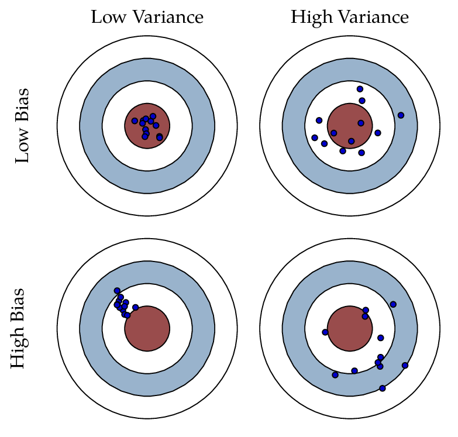

## Unbiasedness of the sample mean

- Assume that each of our observations in the sample $Y_i \sim ?(\mu, \sigma^2)$ come from the **same** population with a **finite** mean.
- Can we show that this estimator has zero **bias**?
  - In other words, is its **expected value** equal to the true parameter value?
- Start by writing down our estimator and taking the expectation

  $$\mathbb{E}[\hat{\mu}] = \mathbb{E}\left[\frac{1}{n}\sum_{i=1}^n Y_i\right]$$
- Next we use linearity of expectations

  $$\mathbb{E}[\hat{\mu}] = \mathbb{E}\left[\frac{1}{n}\sum_{i=1}^n Y_i\right] = \frac{1}{n}\mathbb{E}\left[\sum_{i=1}^n Y_i\right] = \frac{1}{n}\sum_{i=1}^n \mathbb{E}\left[Y_i\right]$$

## Unbiasedness of the sample mean

- Finally, under our assumption that all $Y_i$ come from the population of interest with expectation $\mu$

  $$\frac{1}{n}\sum_{i=1}^n \mathbb{E}\left[Y_i\right] = \frac{1}{n}\sum_{i=1}^n \mu = \frac{n \mu}{n} = \mu$$
- Therefore, the bias, $\text{Bias}(\hat{\mu}) = \mathbb{E}[\hat{\mu}] - \mu = 0$

## Unbiasedness of the sample mean

## Sampling variance of the sample mean

- What else can we learn about the distribution of an estimator?
  - Remember, an **estimator** is a random variable.
  - We’ll refer to the distributions of estimators as **sampling distributions**
- We’ve established $\mathbb{E}[\hat{\mu}]$…now what about $\Var(\hat{\mu})$?
  - How far do draws from our estimator tend to land from its expectation?
- Why do we want to know this?
  - So we can characterize the degree of **uncertainty** in our particular realization of the estimator.
  - Confidence intervals, hypothesis tests, etc… (next few weeks!)

## Sampling variance of the sample mean

- Let’s take the variance of $\hat{\mu}$

  $$\Var(\hat{\mu}) = \Var\left(\frac{1}{n}\sum_{i=1}^n Y_i\right)$$
- Constants come out of a variance **squared**

  $$\Var(\hat{\mu}) = \Var\left(\frac{1}{n}\sum_{i=1}^n Y_i\right) = \frac{1}{n^2}\Var\left(\sum_{i=1}^n Y_i\right)$$
- The variance of a sum is the sum of the variances **plus** all of the covariances

  $$\frac{1}{n^2}\Var\left(\sum_{i=1}^n Y_i\right) = \frac{1}{n^2}\left[\sum_{i=1}^n \Var(Y_i) + \sum_{i=1}^n \sum_{j \neq i} \Cov(Y_i, Y_j)\right]$$

## Sampling variance of the sample mean

- Under **independence**, all of the covariance terms are zero: $\Cov(Y_i, Y_j) = 0$ for $i \neq j$

  $$\frac{1}{n^2}\left[\sum_{i=1}^n \Var(Y_i) + \sum_{i=1}^n \sum_{j \neq i} \Cov(Y_i, Y_j)\right] = \frac{1}{n^2}\sum_{i=1}^n \Var(Y_i)$$
- Under the assumption that each observation comes from the **same** target distribution, every observation has the same **population** variance $\Var(Y_i) = \sigma^2$

  $$\frac{1}{n^2}\sum_{i=1}^n \Var(Y_i) = \frac{1}{n^2}\sum_{i=1}^n \sigma^2 = \frac{n\sigma^2}{n^2} = \frac{\sigma^2}{n}$$

## Sampling variance of the sample mean

- So under i.i.d. sampling, our **sampling variance** is

  $$\Var(\hat{\mu}) = \frac{\sigma^2}{n}$$
- We’ll also often talk about the standard deviation (square root of the variance) of a sampling distribution
  - For estimators we refer to this particular standard deviation as a **standard error**

  $$\text{SE}(\hat{\mu}) = \sqrt{\Var(\hat{\mu})} = \frac{\sigma}{\sqrt{n}}$$
- Note what we needed for unbiasedness: **identical** sampling
  - But this variance expression requires: **identical** and **independent** draws.
  - What happens with dependence? We’ll have a *different* expression for the standard error.
- What happens as $n$ gets large?
  - The **standard error** gets smaller! Our estimator becomes more **precise**.

## Sampling variance of the sample mean

## The sampling distribution of an estimator

- Under i.i.d. $Y_i$, the **sampling distribution** of $\hat{\mu}$ has mean $\mu$ and variance $\sigma^2/n$
- Is that enough to pin down its full **distribution**? Not quite yet!
- A **detour** into **large-sample approximations** gets us an answer *without* more assumptions on $Y_i \sim ?(\mu, \sigma^2)$

## Asymptotic properties

- Another way of talking about properties of estimators is to consider how they **behave** as the sample size gets large.
  - Sometimes this is just *easier* than working with finite sample expectations.
  - Additionally, we might have a **biased** estimator. Does that bias “go away” in large samples?
- This requires us to talk about **sequences** of estimators indexed (typically) by sample size.
  - We’ll typically denote this sequence with a subscript - for example, for the sample mean…
    $$\bar{Y}_n = \{\bar{Y}_1, \bar{Y}_2, \bar{Y}_3, \dotsc\}$$
- Can we characterize the **limit** of this sequence of estimators?
  - It’s a **random variable**…so we need a slightly different language compared to deterministic series.
  - But a lot of intuitions from convergence of series carry over!

## Convergence in probability

- First, we can talk about the convergence of a sequence to a single **value**
  - There are lots of different forms of convergence here, but the most common that we use is **convergence in probability**
- **Convergence in probability**
  - A sequence of random variables $\hat{\mu}_n$ is said to **converge in probability** to some value $\mu$ if for every $\epsilon > 0$, as $n \to \infty$
    $$\Pr(|\hat{\mu}_n - \mu| \ge \epsilon) \to 0$$
- We’ll denote this as $\hat{\mu}_n \xrightarrow{p} \mu$. You’ll see other texts use the term “plim”
- An **estimator** that converges in probability to the target estimand is called **consistent**.

## Weak Law of Large Numbers

- The **weak law of large numbers** states that the sample means of independent and identically distributed random variables…
  - … **converge in probability** to their population **expected value**
  - Assuming that mean is finite.
- Let’s prove this! We’ll also assume finite variance to make it easier.
  $$P(|\bar{Y}_n - \mu | \ge \epsilon) \to 0$$
- The trick will rely on a known **bound** on how far a random variable can fall from its mean: **Chebyshev’s Inequality**
  - This bound depends on the **variance** of that random variable.
  - And we’ve already shown that the variance of $\hat{\mu} = \frac{1}{n}\sum_{i=1}^n Y_i$ **goes to zero** as $n$ gets large.

## Chebyshev’s Inequality

- For any random variable $X$ with a finite mean and variance, and any $\epsilon > 0$, **Chebyshev’s Inequality** states:

  $$P(|X - \mathbb{E}[X]| \ge \epsilon) \le \frac{\Var(X)}{\epsilon^2}$$
- The chance of landing far from the mean is **bounded** by the variance
  - Holds for **any** distribution with a finite variance

## Weak Law of Large Numbers

- Apply Chebyshev’s inequality to the sample mean, which has $\mathbb{E}[\bar{Y}_n] = \mu$ and $\Var(\bar{Y}_n) = \frac{\sigma^2}{n}$

  $$P(|\bar{Y}_n - \mu| \ge \epsilon) \le \frac{\Var(\bar{Y}_n)}{\epsilon^2} = \frac{\sigma^2}{n\epsilon^2}$$
- For any fixed $\epsilon > 0$, the right-hand side goes to zero as $n$ gets large

  $$\lim_{n \to \infty} \frac{\sigma^2}{n\epsilon^2} = 0$$
- A probability can’t be negative, so it’s squeezed between $0$ and something going to $0$

  $$P(|\bar{Y}_n - \mu| \ge \epsilon) \to 0$$
- Therefore, $\bar{Y}_n \xrightarrow{p} \mu$: the sample mean is **consistent** for the population mean

## Weak Law of Large Numbers

## Properties of convergence in probability

- Consider two sequences $X_n \xrightarrow{p} x$ and $Y_n \xrightarrow{p} y$ and continuous function $g()$.
- By the continuous mapping theorem
1. $X_n + Y_n \xrightarrow{p} x + y$
2. $X_nY_n \xrightarrow{p} xy$
3. $X_n/Y_n \xrightarrow{p} x/y$ if $y \neq 0$
4. $g(X_n) \xrightarrow{p} g(x)$

## Running Example: 2024 General Social Survey

- In our particular sample, the **sample mean** estimator gives an estimated turnout of $\hat{\mu} = 0.778$
- We can estimate the population **variance** in a similar manner (we’ll spend more time on this next week): plug in the **sample variance**

  $$\hat{\sigma}^2 = \frac{1}{n-1}\sum_{i=1}^n (Y_i - \bar{Y}_n)^2 = 0.173$$
- So we computed a guess of $0.778$
  - And we think it came from a distribution centered on the **truth** with a **standard error** of $\sqrt{\hat{\sigma}^2/n} = 0.0072$
- The Census reports that the true turnout rate in 2020 was $0.668$ (Fabina and Scherer 2022)
- What drives the error?
  - **Sampling error**: Noise due to the fact that the sample isn’t the same as the population - what we can talk about.
  - **Non-sampling error**: Our sample isn’t drawn from a distribution with expected turnout $0.668$ - it’s coming from a *different* distribution.

## Running Example: 2024 GSS in R

```r
truth <- 0.668   # Census CPS: share of citizens 18+ who voted in 2020

gss_se <- gss |>
  summarize(n = n(),
            ybar = mean(voted20),
            s2 = var(voted20),
            se = sqrt(s2 / n),
            ybar_w = weighted.mean(voted20, weight))
gss_se
```

```
# A tibble: 1 × 5
      n  ybar    s2      se ybar_w
  <int> <dbl> <dbl>   <dbl>  <dbl>
1  3373 0.778 0.173 0.00716  0.770
```

## The challenges of inference!

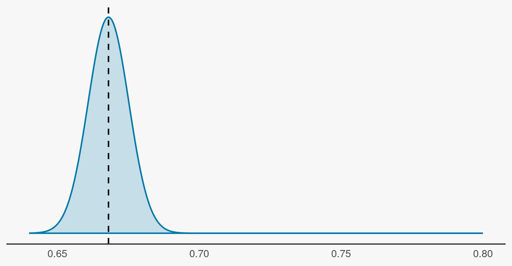

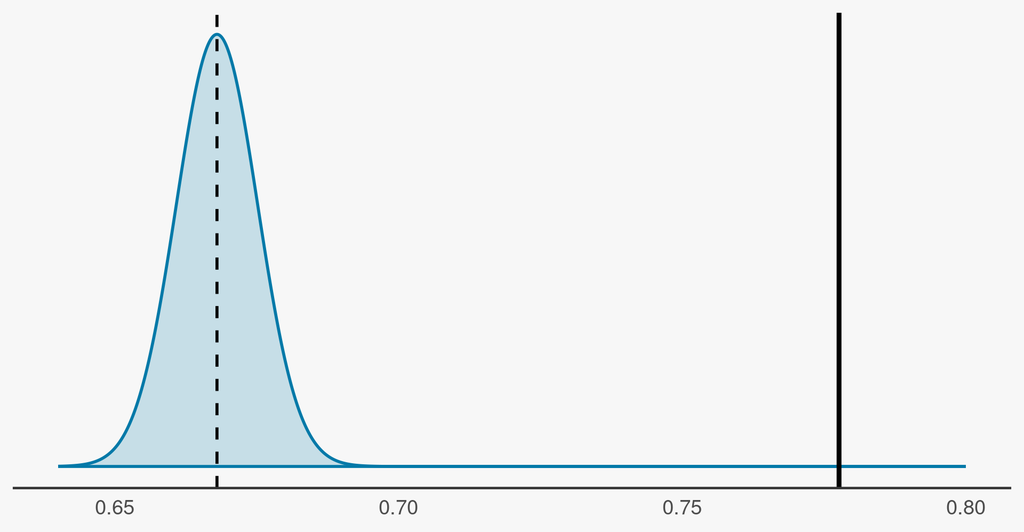

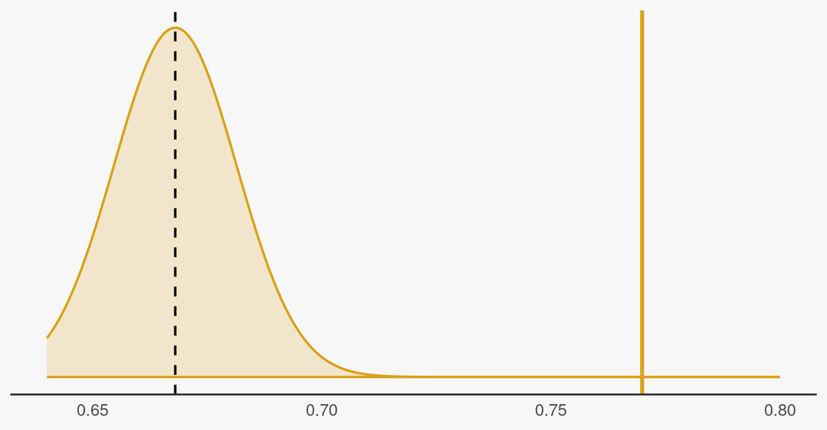

## Next week

- Estimation, continued
  - Convergence in distribution and the **central limit theorem**
  - **Plug-in** estimators
  - Density estimation

## References

Blackwell, Matthew. 2025. *A User’s Guide to Statistical Inference and Regression*. https://mattblackwell.github.io/gov2002-book/.

Fabina, Jacob, and Zachary Scherer. 2022. “Voting and Registration in the Election of November 2020.” Current Population Reports P20-585. Washington, DC: U.S. Census Bureau. https://www.census.gov/content/dam/Census/library/publications/2022/demo/p20-585.pdf.